# Brownlows Bets

Ana Preciado

Year 2019

### 0.0.1 2019-05-02

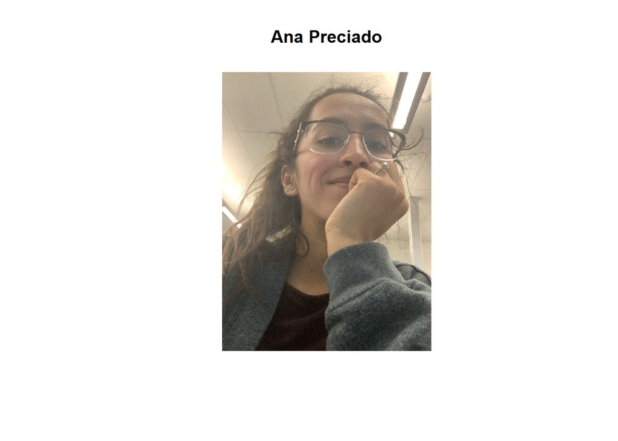

# 1 Introduction

At the first day of class there are 35 students in Math Statistics class and professor Brownlow always proposes this bet to his students “I will wager $2 to your bet of $1 that at least two people in today’s class have the same birthday. He tells me he has made that bet 1137 times so far. Where do you think his profits are? Discuss this in a markdown document.

# 2 Methods

We will construct a variety store to show Brownlow’s earnings. to show the .95 of his earnings, we just have to take from .25 to the .95 off of our histogram. Number represent peoples birthdays. We’re going to sample with replacement. So if we pick 35 numbers its like picking 35 people. We repeat this 1135 times. If our duplicated sample is over 0 then Brownlow wins $1, but if it is not over 0 then Brownlow loses $2. In the end once we’ve done it 1135 times we’ll see how much Brownlow ends up profiting. We’re interested in finding the middle 95% of that stuff.

# 3 Profit Estimate

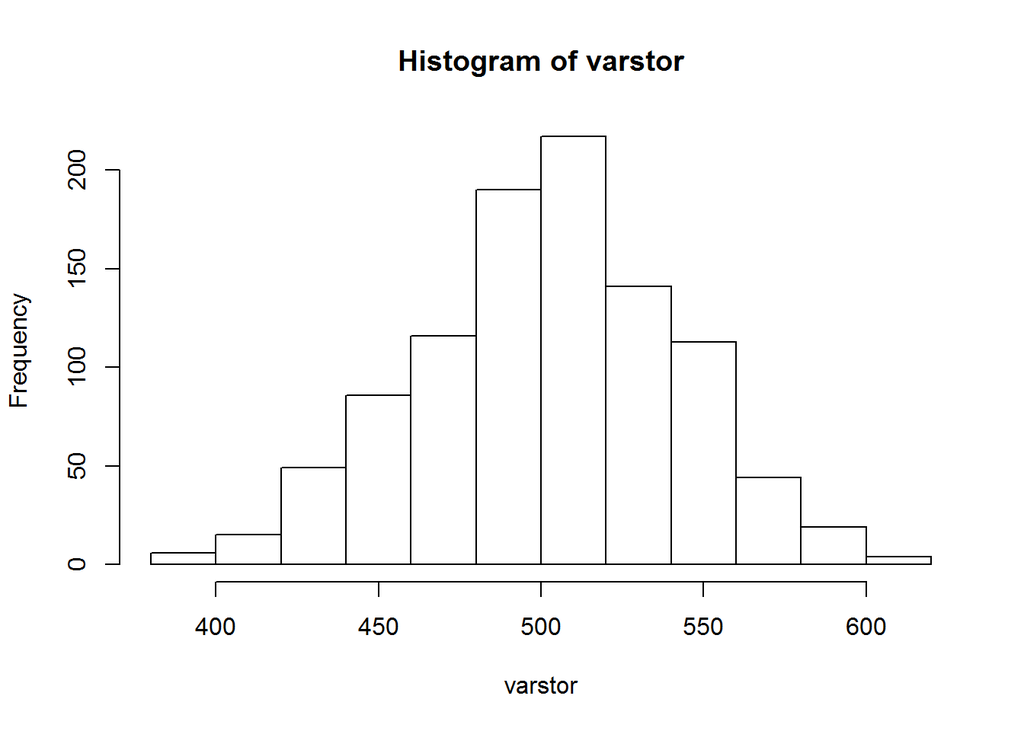

```r
days=1:365
count=1135
repeatn=1000
varstor=numeric()
for (j in 1:repeatn){
brownlow = 0
for (i in 1:count) {
  sam=sample(days,size=35,replace = T)
  y=duplicated(sam)
  if (sum(y)>0) brownlow=brownlow+1
  else brownlow = brownlow - 2
}
varstor[j]=brownlow
}
hist(varstor)
```

```r
var(varstor)
```

```
## [1] 1569.724
```

# 4 Confidence interval of Brownlows earning

In order to come up with the 95% interval we need to sort varstor. After we sort varstor we take the lowest interval “25” and the highest interval “975”. The low and high interval will not always be the same, but for this interval the low was 424 and the high was 589. If we ran our initial r block and then ran the svarstor block again, the results would be close to the same, but not the same.

```r
svarstor <- sort(varstor)
low = svarstor [25]
high = svarstor [975]
```

# 5 Discussion and Conclusion